# Data Wrangling Example

The ISDL Property Management (ISDL-PM) Dataset

# Task

Given the following relational data schema of the ISDL Property Management LC (see Figure 1). The foreign keys are indicated with (FK) in the schema. As a junior data scientist, you have been asked to apply your new knowledge of the R Library dplyr and complete the following tasks.

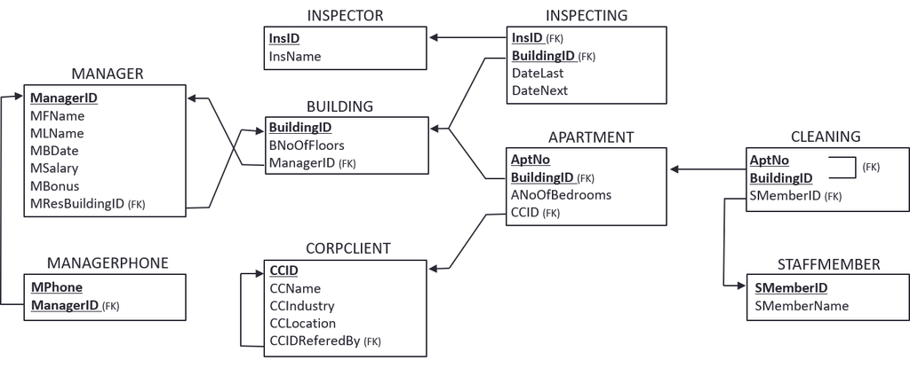

Figure 1: relational data schema of the ISDL property management LC

## Import data

In the following, we import the data from the GitHub directory (https://github.com/VAWi-DataScience/2021/tree/main/Lecture/03_Data%20Wrangling/data)

## Inspect the data

```
## [1] "Inspector"
```

```
## Rows: 5
## Columns: 2
## $ InsID   <chr> "I11", "I22", "I33", "I44", "I55"
## $ InsName <chr> "Jane", "Niko", "Mick", "Bianca", "Sergei"
```

```
## [1] "Inspecting"
```

```
## Rows: 13
## Columns: 4
## $ InsID      <chr> "I11", "I11", "I11", "I22", "I22", "I22", "I33", "I33", "I3~
## $ BuildingID <chr> "B1", "B2", "B7", "B2", "B3", "B8", "B3", "B4", "B9", "B4",~
## $ DateLast   <date> 2018-05-15, 2019-02-17, 2012-04-08, 2019-02-17, 2020-01-11~
## $ DateNext   <date> 2020-11-14, 2020-11-17, 2020-12-08, 2020-12-17, 2021-01-11~
```

```
## [1] "Manager"
```

```
## Rows: 6
## Columns: 7
## $ ManagerID      <chr> "M12", "M23", "M34", "M45", "M56", "M67"
## $ MFName         <chr> "Boris", "Austin", "George", "Mariana", "Fiona", "Alexa~
## $ MLName         <chr> "Grant", "Lee", "Sherman", "Gonzalez", "Keane", "Sanbor~
## $ MBDate         <date> 1980-06-20, 1975-10-30, 1976-01-11, 1980-12-27, 1977-10~
## $ MSalary        <dbl> 60000, 50000, 52000, 54000, 57000, 62000
## $ MBonus         <chr> "NULL", "5000.00", "2000.00", "NULL", "2000.00", "3000~
## $ MResBuildingID <chr> "B1", "B2", "B4", "B5", "B7", "B8"
```

```
## [1] "Building"
```

```
## Rows: 9
## Columns: 3
## $ BuildingID  <chr> "B1", "B2", "B3", "B4", "B5", "B6", "B7", "B8", "B9"
## $ BNoOfFloors <dbl> 5, 6, 4, 4, 3, 3, 2, 4, 3
## $ ManagerID   <chr> "M12", "M23", "M23", "M34", "M45", "M45", "M56", "M67", "M~
```

```
## [1] "Apartment"
```

```
## Rows: 45
## Columns: 4
## $ BuildingID    <chr> "B1", "B1", "B1", "B1", "B1", "B2", "B2", "B2", "B2", "B~
## $ AptNo         <dbl> 11, 21, 31, 41, 51, 11, 21, 31, 41, 51, 61, 11, 21, 31, ~
## $ ANoOfBedrooms <dbl> 1, 1, 1, 1, 1, 2, 2, 2, 2, 2, 2, 2, 2, 2, 2, 2, 2, 2, 2,~
## $ CCID          <chr> "C111", "C111", "C333", "NULL", "NULL", "C222", "C222", ~
```

```
## [1] "Cleaning"
```

```
## Rows: 54
## Columns: 3
## $ BuildingID <chr> "B1", "B1", "B1", "B1", "B1", "B2", "B2", "B2", "B2", "B2",~
## $ AptNo      <dbl> 11, 21, 31, 41, 51, 11, 21, 31, 41, 51, 61, 11, 21, 31, 41,~
## $ SMemberID  <dbl> 5432, 5432, 5432, 9876, 9876, 9876, 9876, 5432, 5432, 1028,~
```

```
## [1] "Managerphone"
```

```
## Rows: 10
## Columns: 2
## $ ManagerID <chr> "M12", "M12", "M23", "M34", "M34", "M45", "M56", "M67", "M67~
## $ MPhone    <chr> "555-2222", "555-3232", "555-9988", "555-1003", "555-9999", ~
```

```
## [1] "Corpclient"
```

```
## Rows: 9
## Columns: 5
## $ CCID          <chr> "C111", "C222", "C333", "C444", "C555", "C666", "C777", ~
## $ CCName        <chr> "BlingNotes", "SkyJet", "Xilerate", "NanoCorp", "Enterta~
## $ CCIndustry    <chr> "Music", "Airline", "Sports", "Broadcasting", "Broadcast~
## $ CCLocation    <chr> "Chicago", "Oak Park", "Chicago", "Rosemont", "Oak Brook~
## $ CCIDReferedBy <chr> "NULL", "C111", "NULL", "C111", "NULL", "C444", "C222", ~
```

```
## [1] "Staffmember"
```

```
## Rows: 8
## Columns: 2
## $ SMemberID   <dbl> 1028, 2537, 3984, 4196, 5432, 7652, 8467, 9876
## $ SMemberName <chr> "Franz", "Howard", "Luis", "Arthur", "Brian", "Caroline", ~
```

# Query 1

Show the name of all staff members in ascending order.

```r
query1 <- staffmember %>%
  select(SMemberName) %>%
  arrange(SMemberName) # Sort by name

query1
```

```
## # A tibble: 8 x 1
##   SMemberName
##   <chr>
## 1 Arthur
## 2 Boris
## 3 Brian
## 4 Caroline
## 5 Franz
## 6 Howard
## 7 Luis
## 8 Mariana
```

# Query 2

Show the ID and the name of all corporate clients located in Rosemont or Oak Park.

```r
query_2 <- corpclient %>%
  filter(CCLocation == "Rosemont" | CCLocation == "Oak Park") %>%
  select(CCID, CCName)

#Alternative with %in%
location <- c("Rosemont","Oak Park")
query_2 <- corpclient %>%
  filter(CCLocation %in%location) %>%
  select(CCID, CCName)

query_2
```

```
## # A tibble: 3 x 2
##   CCID  CCName
##   <chr> <chr>
## 1 C222  SkyJet
## 2 C444  NanoCorp
## 3 C888  SouthAlps
```

# Query 3

Show the `BuildingID` the number of floors of the building and the lastname of the responsible manager.

```r
query_3 <- building %>%
  left_join(manager, by="ManagerID") %>%
  select(BuildingID, BNoOfFloors, MLName)

query_3
```

```
## # A tibble: 9 x 3
##   BuildingID BNoOfFloors MLName
##   <chr>            <dbl> <chr>
## 1 B1                   5 Grant
## 2 B2                   6 Lee
## 3 B3                   4 Lee
## 4 B4                   4 Sherman
## 5 B5                   3 Gonzalez
## 6 B6                   3 Gonzalez
## 7 B7                   2 Keane
## 8 B8                   4 Sanborn
## 9 B9                   3 Sanborn
```

# Query 4

Show all manager (`MFName` and `MFFname`), who have a salary (`MSalary`) less than 55.000 and manage at least two buildings.

```r
query_4 <- building %>%
  group_by(ManagerID) %>%
  summarise(NumberOfBuildings = n()) %>% #Because there are only groups of one we get a notification in the console. We can turnout these messages in the settings of the code-junk
  left_join(manager, by="ManagerID") %>%
  filter( MSalary < 55000) %>% #Filter based on `MSalary`
  filter(NumberOfBuildings >= 2) %>%
  select(MFName, MLName, MSalary)

query_4
```

```
## # A tibble: 2 x 3
##   MFName  MLName   MSalary
##   <chr>   <chr>      <dbl>
## 1 Austin  Lee        50000
## 2 Mariana Gonzalez   54000
```

# Query 5

Show the ID of the inspector (`InsID`) and the name (`InsName`) for all inspectors having a inspection in 2021. Show the same results only once.

```r
query_5 <- inspecting %>%
  filter(DateNext > as.Date("2021-01-01")) %>% #Column should be in date format. Either when importing or here by casting the type
  inner_join(inspector, by="InsID") %>%
  select(InsID, InsName) %>%
  distinct()

query_5
```

```
## # A tibble: 4 x 2
##   InsID InsName
##   <chr> <chr>
## 1 I22   Niko
## 2 I33   Mick
## 3 I44   Bianca
## 4 I55   Sergei
```

# Query 6

Show the id of the (`SMemberID`) and the name (`SMemberName`) staff members who clean apartments for corporate clients located in Chicago.

```r
query_6 <- corpclient %>%
  filter(CCLocation == "Chicago") %>%
  inner_join(apartment, by = "CCID") %>%
  inner_join(cleaning, by = c("AptNo", "BuildingID")) %>% #Join data with double foreign key
  inner_join(staffmember, by = "SMemberID") %>%
  select(SMemberID, SMemberName) %>%
  distinct()
query_6
```

```
## # A tibble: 7 x 2
##   SMemberID SMemberName
##       <dbl> <chr>
## 1      5432 Brian
## 2      1028 Franz
## 3      3984 Luis
## 4      9876 Boris
## 5      2537 Howard
## 6      8467 Mariana
## 7      7652 Caroline
```

# Query 7

Show all the corporate client id (`CCID`),name(`CCName`)and the name of the corporate client that referred the respective corporate client.

```r
query_7 <- corpclient %>%

  inner_join(corpclient, c( "CCIDReferedBy" = "CCID"), suffix=c("","_ReferredBy")) %>% #Self join with a suffix for the new columns
  select(CCID,CCName, ReferredByCCName=CCName_ReferredBy)
```